# POVMs (Positive operator-valued measurements)

Em português, seria "medidas valoradas por operadores positivos" (MVOPs).

## Medidas projetivas

Consideremos um sistema com espaço de estados $\mathcal{H}_{A}.$ Observáveis desse sistema são descritos por operadores Hermitianos \begin{equation} A=\sum_{j=1}^{d_{A}}a_{j}\Pi_{a_{j}} \end{equation} com \begin{equation} a_{j}\in\mathbb{R} \text{, } \Pi_{a_{j}}=|a_{j}\rangle\langle a_{j}| \text{, } \Pi_{a_{j}}\Pi_{a_{k}}=\delta_{jk}\Pi_{a_{j}} \text{ e } \sum_{j=1}^{d_{A}}\Pi_{a_{j}}=\mathbb{I}_{A}. \end{equation} Os operadores $\Pi_{a_{j}}$ são chamados de projetores (ficará claro o motivo a seguir). Na forma como escrevemos acima, eles são projetores unidimensionais ou de rank 1, pois o subespaço gerado pelo autovetor correspondete, $|a_{j}\rangle$, tem dimensão igual a 1. Claro, podemos ter projetores com qualquer rank. Por exemplo, se os dois autovalores $a_{1}$ e $a_{2}$ são degenerados, i.e., tem o mesmo valor, então qualquer combinação linear \begin{equation} c_{1}|a_{1}\rangle + c_{2}|a_{2}\rangle \end{equation} também é um autovetor de $A$ correspondente ao mesmo autovalor $a_{1}=a_{2}=:a_{12}$. Nesse caso, poderíamos escrever \begin{equation} A= a_{12}\Pi_{a_{12}}+\sum_{j=3}^{d_{A}}a_{j}\Pi_{a_{j}}. \end{equation} O projetor $\Pi_{a_{12}}$ tem rank 2 pois envolve dois vetores ortogonais que geram um subespaço bidimensional. Uma possibilidade seria $\Pi_{a_{12}}=\Pi_{a_{1}}+\Pi_{a_{2}}$, mas existem infinitas outras.

Bom, e por que chamamos esses opedores de projetores. Considere que nosso sistema $\mathcal{H}_{A}$ foi preparado em um estado qualquer $|\psi\rangle$ e medimos o observável $A$. Existem evidências experimentais que nos levam ao **postulado da repetibilidade**, que diz que se medimos um observável $A$ e obtemos o autovalor correspondente a $|a_{j}\rangle$ e fazemos medidas subsequentes, uma imediatamente depois da outra (ou isolamos completamente o sistema entre medidas) obteremos 100% da vezes o resultado $|a_{j}\rangle$. Ou seja \begin{equation} |\psi\rangle \xrightarrow[\text{obtém } a_{j}]{\text{mede } A} |a_{j}\rangle = \frac{|a_{j}\rangle\langle a_{j}|\psi\rangle}{|||a_{j}\rangle\langle a_{j}|\psi\rangle||} = \frac{\Pi_{a_{j}}|\psi\rangle}{||\Pi_{a_{j}}|\psi\rangle||}. \end{equation} Como o estado antes da medida pode ser escrito como \begin{equation} |\psi\rangle = \sum_{j=1}^{d_{A}}c_{j}|a_{j}\rangle = \sum_{j=1}^{d_{A}}\langle a_{j}|\psi\rangle|a_{j}\rangle, \end{equation} se $a_{j}$ é obtido ao medir $A$, então o estado $|\psi\rangle$ é projetado na direção de $|a_{j}\rangle$, uma "ação" que pode ser descrita pelo operador $\Pi_{a_{j}}.$

Agora, se temos incerteza sobre a preparação do estado do sistema e este é descrito pelo operador densidade \begin{equation} \rho = \sum_{k}p_{k}|\psi_{k}\rangle\langle\psi_{k}|, \end{equation} com $0\le p_{k}\le 1$, $\sum_{k}p_{k}=1$ e $|\psi_{k}\rangle$, pela interpretação do ensemble \begin{equation} \rho \equiv \{p_{k},|\psi_{k}\rangle\}, \end{equation} teremos que, ao medir $A$ e obter $a_{j}$, se o estado do sistema for $|\psi_{k}\rangle$ então será projetado para \begin{equation} |\psi_{k}\rangle \xrightarrow[\text{obtém } a_{j}]{\text{mede } A} |a_{j}\rangle = \frac{\Pi_{a_{j}}|\psi_{k}\rangle}{||\Pi_{a_{j}}|\psi_{k}\rangle||}. \end{equation} Aplicando ao operador densidade, teremos \begin{equation} \rho \xrightarrow[\text{obtém } a_{j}]{\text{mede } A} \frac{\sum_{k}p_{k}\Pi_{a_{j}}|\psi_{k}\rangle\langle\psi_{k}|\Pi_{a_{j}}}{Tr\big(\sum_{k}p_{k}\Pi_{a_{j}}|\psi_{k}\rangle\langle\psi_{k}|\Pi_{a_{j}}\big)} = \frac{\Pi_{a_{j}}\rho\Pi_{a_{j}}}{Tr\big(\Pi_{a_{j}}\rho\Pi_{a_{j}}\big)}, \end{equation}

Vale observar, relacionado a probabilidades, que pela regra de Born teremos \begin{align} Pr(a_{j}|\psi) & = |\langle a_{j}|\psi\rangle|^{2} \\ & = \langle\psi|a_{j}\rangle\langle a_{j}|\psi\rangle = \langle\psi|\Pi_{a_{j}}|\psi\rangle = Tr(\Pi_{a_{j}}|\psi\rangle\langle\psi|) \end{align} e \begin{align} Pr(a_{j}|\rho) & = \sum_{k}p_{k}Pr(a_{j}|\psi_{k}) = \sum_{k}p_{k}Tr(\Pi_{a_{j}}|\psi_{k}\rangle\langle\psi_{k}|) \\ & = Tr\big(\Pi_{a_{j}}\sum_{k}p_{k}|\psi_{k}\rangle\langle\psi_{k}|\big) = Tr\big(\Pi_{a_{j}}\rho\big) = Tr\big(\Pi_{a_{j}}\rho\Pi_{a_{j}}\big). \end{align}

## Medidas MVOPs

Uma maneira simples de introduzir a razoabilidade de usarmos MVOPs é usando \begin{align} Pr(a_{j}|\psi) & = \langle\psi|\Pi_{a_{j}}|\psi\rangle = \langle\psi|\Pi_{a_{j}}\Pi_{a_{j}}|\psi\rangle = \langle\psi|\Pi_{a_{j}}^{\dagger}\Pi_{a_{j}}|\psi\rangle \\ & =: \langle\psi|E_{j}|\psi\rangle, \end{align} onde definimos \begin{equation} E_{j} := \Pi_{a_{j}}^{\dagger}\Pi_{a_{j}}. \end{equation} É fácil ver que esses operadores são positivos semidefinidos: \begin{equation} \langle\psi|E_{j}|\psi\rangle = \langle\psi|\Pi_{a_{j}}^{\dagger}\Pi_{a_{j}}|\psi\rangle = \langle\phi|\phi\rangle\ge0 \ \therefore\ E_{j}\ge\mathbb{O}. \end{equation} Ademais, como para $\Pi_{a_{j}}$ sendo projetores temos \begin{equation} E_{j} = \Pi_{a_{j}}^{\dagger}\Pi_{a_{j}} = \Pi_{a_{j}}\Pi_{a_{j}} = \Pi_{a_{j}}^{2} = \Pi_{a_{j}}, \end{equation} vem que \begin{equation} \sum_{j}E_{j} = \sum_{j}\Pi_{a_{j}} = \mathbb{I}_{A}. \end{equation}

Visto isto, podemos supor que qualquer conjunto de operadores \begin{equation} E_{j} = M_{j}^{\dagger}M_{j}, \end{equation} com $M_{j}$ sendo operadores lineares quaisquer em $\mathcal{H}_{A}$ (não necessariamente projetores), tais que \begin{equation} E_{j}\le \mathbb{I}_{A} \text{ e } \sum_{j}E_{j} = \mathbb{I}_{A}, \end{equation} nos fornecerá uma distribuição válida de probabilidades pois \begin{align} Pr(E_{j}|\rho) = \sum_{k}p_{k}Pr(E_{j}|\psi_{k}\rangle) := \sum_{k}p_{k}\langle\psi_{k}|E_{j}|\psi_{k}\rangle \ge 0 \end{align} e \begin{align} \sum_{j}Pr(E_{j}|\rho) & = \sum_{j}\sum_{k}p_{k}\langle\psi_{k}|E_{j}|\psi_{k}\rangle = \sum_{k}p_{k}\langle\psi_{k}|\sum_{j}E_{j}|\psi_{k}\rangle \\ & = \sum_{k}p_{k}\langle\psi_{k}|\mathbb{I}_{A}|\psi_{k}\rangle = \sum_{k}p_{k} = 1. \end{align}

Uma grande diferença em relação a medidas projetivas é que, como $M_{j}$ são operadores quaisquer que satisfazem $\sum_{j}M_{j}^{\dagger}M_{j}=\mathbb{I}_{A}$, o número de elementos $\{E_{j}\}$ da MVOPs pode ser menor, igual ou maior que a dimensão do espaço de estados $\mathcal{H}_{A}.$

## Aplicação em distinguibilidade de estados

### Teorema

É impossível distinguir estados não ortogonais usando medidas projetivas.

#### Prova

Considere que um qubit é preparado em um dos estados não ortogonais conhecidos \begin{equation} |\psi_{1}\rangle \text{ ou } |\psi_{2}\rangle \text{, com } \langle\psi_{1}|\psi_{2}\rangle\ne0, \end{equation} mas não sabemos em qual. Queremos, medindo algum observável deste sistema, determinar com certeza em qual estado o sistema foi preparado. Vamos provar que isso é impossível por contradição. Se for possível, então teremos projetores $\Pi_{1}$ e $\Pi_{2}$ tais que \begin{equation} Pr(\Pi_{1}|\psi_{1}) = \langle\psi_{1}|\Pi_{1}|\psi_{1}\rangle = 1 \text{ e } Pr(\Pi_{2}|\psi_{2}) = \langle\psi_{2}|\Pi_{2}|\psi_{2}\rangle = 1, \end{equation} com $\Pi_{1}\Pi_{1}=\Pi_{1}$, $\Pi_{2}\Pi_{2}=\Pi_{2}$, $\Pi_{1}\Pi_{2}=\mathbb{O}$ e $\Pi_{1}+\Pi_{2}=\mathbb{I}$. Seguindo, escrevemos \begin{equation} |\psi_{2}\rangle = \alpha|\psi_{1}\rangle+\beta|\phi\rangle \end{equation} com $\langle\phi|\psi_{1}\rangle=0$, $|\alpha|^{2}+|\beta|^{2}=1$ e $|\beta|<1$ pois $|\psi_{2}\rangle$ e $|\psi_{1}\rangle$ não são ortogonais. Usando \begin{align} \langle\phi|\Pi_{2}|\phi\rangle & < \langle\phi|\Pi_{1}|\phi\rangle + \langle\phi|\Pi_{2}|\phi\rangle = \langle\phi|(\Pi_{1}+\Pi_{2})|\phi\rangle = \langle\phi|\mathbb{I}|\phi\rangle = 1 \end{align}

e \begin{align} & 1 = \langle\psi_{1}|\mathbb{I}|\psi_{1}\rangle = \langle\psi_{1}|(\Pi_{1}+\Pi_{2})|\psi_{1}\rangle = \langle\psi_{1}|\Pi_{1}|\psi_{1}\rangle + \langle\psi_{1}|\Pi_{2}|\psi_{1}\rangle \\ & = 1 + \langle\psi_{1}|\Pi_{2}|\psi_{1}\rangle \\ & \therefore \langle\psi_{1}|\Pi_{2}|\psi_{1}\rangle = \langle\psi_{1}|\sqrt{\Pi_{2}}\sqrt{\Pi_{2}}|\psi_{1}\rangle = 0 \ \therefore\ \sqrt{\Pi_{2}}|\psi_{1}\rangle=|\oslash\rangle \end{align} vem que \begin{align} \langle\psi_{2}|\Pi_{2}|\psi_{2}\rangle & = \big(\alpha^{*}\langle\psi_{1}|+\beta^{*}\langle\phi|\big)\Pi_{2}\big(\alpha|\psi_{1}\rangle+\beta|\phi\rangle\big) \\ & = |\alpha|^{2}\langle\psi_{1}|\Pi_{2}|\psi_{1}\rangle + \alpha^{*}\beta\langle\psi_{1}|\Pi_{2}|\phi\rangle + \alpha\beta^{*}\langle\phi|\Pi_{2}|\psi_{1}\rangle + |\beta|^{2}\langle\phi|\Pi_{2}|\phi\rangle \\ & = 0 + \alpha^{*}\beta\langle\psi_{1}|\sqrt{\Pi_{2}}\sqrt{\Pi_{2}}|\phi\rangle + \alpha\beta^{*}\langle\phi|\sqrt{\Pi_{2}}\sqrt{\Pi_{2}}|\psi_{1}\rangle + |\beta|^{2}\langle\phi|\Pi_{2}|\phi\rangle \\ & = \alpha^{*}\beta\langle\oslash|\sqrt{\Pi_{2}}|\phi\rangle + \alpha\beta^{*}\langle\phi|\sqrt{\Pi_{2}}|\oslash\rangle + |\beta|^{2}\langle\phi|\Pi_{2}|\phi\rangle \\ & = 0 + 0 + |\beta|^{2}\langle\phi|\Pi_{2}|\phi\rangle \\ & \le |\beta|^{2} < 1. \end{align} Mas isso contradiz nossa suposição inicial (de que $\langle\psi_{2}|\Pi_{2}|\psi_{2}\rangle=1$), mostrando assim que não é possível distuinguir estados não ortogonais usando medidas projetivas. $\hspace{2cm} \square$

### Usando MVOPs para distuinguir estados não ortogonais

Vamos considerar uma medida MVOP com elementos \begin{align} & E_{1} = \frac{\sqrt{2}}{1+\sqrt{2}}|\psi_{1}^{\perp}\rangle\langle \psi_{1}^{\perp}|, \\ & E_{2} = \frac{\sqrt{2}}{1+\sqrt{2}}|\psi_{2}^{\perp}\rangle\langle \psi_{2}^{\perp}|, \\ & E_{3} = \mathbb{I} - E_{1} - E_{2}. \end{align} É fácil ver que eles satisfazem as condições exigidas para os elementos de uma MVOP.

Para sistemas de dois níveis, $|\psi_{1}^{\perp}\rangle$ e $|\psi_{2}^{\perp}\rangle$ são unicamente definidos. Vemos que \begin{align} & |\psi_{1}\rangle \text{ foi preparado } \therefore\ Pr(E_{1}) = \langle\psi_{1}|E_{1}|\psi_{1}\rangle = 0, \\ & |\psi_{2}\rangle \text{ foi preparado } \therefore\ Pr(E_{2}) = \langle\psi_{2}|E_{2}|\psi_{2}\rangle = 0. \end{align} Por conseguinte, se ao fazer a medida MVOP com os elementos $\{E_{1},E_{2},E_{3}\}$ temos: \begin{align} & \text{Obtém } E_{1}\ \therefore\ \text{ o estado preparado foi } |\psi_{2}\rangle, \\ & \text{Obtém } E_{2}\ \therefore\ \text{ o estado preparado foi } |\psi_{1}\rangle, \\ & \text{Obtém } E_{3}\ \therefore\ \text{ não podemos concluir nada. } \end{align} Vemos assim que essa medida POVM nos possibilita distinguir perfeitamente qual dos dois estados foi preparado, com o ônus de que quando o resultado $E_{3}$ for obtido não podemos concluir nada sobre a preparação de estado.

Vamos analisar agora a frequência relativa com que a MVOP não nos permite concluir nada a respeito do estado preparado. Teremos que \begin{align} Pr(E_{3}) & = Pr(E_{3}|\psi_{1}) + Pr(E_{3}|\psi_{2}) \\ & = \langle\psi_{1}|E_{3}|\psi_{1}\rangle + \langle\psi_{2}|E_{3}|\psi_{2}\rangle \\ & = \langle\psi_{1}|(\mathbb{I} - E_{1} - E_{2})|\psi_{1}\rangle + \langle\psi_{2}|(\mathbb{I} - E_{1} - E_{2})|\psi_{2}\rangle \\ & = 1 - \langle\psi_{1}|E_{1}|\psi_{1}\rangle - \langle\psi_{1}|E_{2}|\psi_{1}\rangle + 1 - \langle\psi_{2}|E_{1}|\psi_{2}\rangle - \langle\psi_{2}|E_{2}|\psi_{2}\rangle \\ & = 2 - 0 - Pr(E_{2}|\psi_{1}) - Pr(E_{1}|\psi_{2}) - 0. \end{align}

Vamos considerar como exemplo \begin{align} & |\psi_{1}\rangle = |0\rangle, \\ & |\psi_{2}\rangle = \cos(\theta/2)|0\rangle + e^{i\phi}\sin(\theta/2)|1\rangle. \end{align} Nesse caso teremos que \begin{align} & E_{1} = \frac{\sqrt{2}}{1+\sqrt{2}}|1\rangle\langle 1|, \\ & E_{2} = \frac{\sqrt{2}}{1+\sqrt{2}}|n_{+}^{\perp}\rangle\langle n_{+}^{\perp}|, \\ \end{align} com $|n_{+}^{\perp}\rangle=-\sin(\theta/2)|0\rangle+e^{i\phi}\cos(\theta/2)|1\rangle$.

Assim \begin{align} Pr(E_{1}|\psi_{2}) & = \langle\psi_{2}|E_{1}|\psi_{2}\rangle \\ & = \langle\psi_{2}|\frac{\sqrt{2}}{1+\sqrt{2}}|1\rangle\langle 1|\big(\cos(\theta/2)|0\rangle + e^{i\phi}\sin(\theta/2)|1\rangle\big) \\ & = \frac{\sqrt{2}}{1+\sqrt{2}} \big(\cos(\theta/2)\langle 0| + e^{-i\phi}\sin(\theta/2)\langle 1|\big)e^{i\phi}\sin(\theta/2)|1\rangle \\ & = \frac{\sqrt{2}\sin^{2}(\theta/2)}{1+\sqrt{2}} \end{align} e \begin{align} Pr(E_{2}|\psi_{1}) & = \langle\psi_{1}|E_{2}|\psi_{1}\rangle = \langle 0|\frac{\sqrt{2}}{1+\sqrt{2}}|n_{+}^{\perp}\rangle\langle n_{+}^{\perp}|0\rangle \\ & = \frac{\sqrt{2}}{1+\sqrt{2}}\langle 0|\big(-\sin(\theta/2)|0\rangle+e^{i\phi}\cos(\theta/2)|1\rangle\big)\big(-\sin(\theta/2)\langle 0|+e^{-i\phi}\cos(\theta/2)\langle 1|\big)|0\rangle \\ & = \frac{\sqrt{2}\sin^{2}(\theta/2)}{1+\sqrt{2}}. \end{align} Com isso, obtemos \begin{equation} Pr(E_{3}) = 2 \Big(1-\frac{\sqrt{2}\sin^{2}(\theta/2)}{1+\sqrt{2}}\Big). \end{equation}

```python
import numpy as np
import matplotlib
from matplotlib import pyplot as plt
import math
```

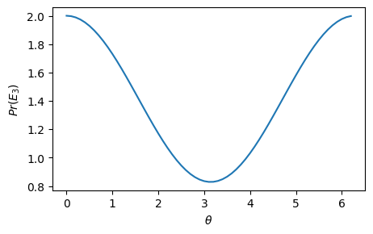

```python
th = np.arange(0, 2*math.pi, 0.1); prE3 = 2*(1-(math.sqrt(2)*(np.sin(th/2)**2))/(1+math.sqrt(2)))
matplotlib.rcParams.update({'font.size':10})
plt.figure(figsize = (5,3), dpi = 100)
plt.plot(th, prE3); plt.xlabel(r'$\theta$'); plt.ylabel(r'$Pr(E_{3})$'); plt.show()
```

Em geral, a probabilidade de resposta inclonclusiva é bem alta. É $>0.8$ mesmo para estados ortogonais $|\psi_{1}\rangle=|0\rangle$ e $|\psi_{1}(\theta=\pi)\rangle=|1\rangle$.

Note que a probabilidade $Pr(E_{3})$ pode ser $>1$, poder ser inclusive $=2$ pois estamos considerando duas preparações de estado, de $|\psi_{1}\rangle$ e de $|\psi_{2}\rangle$.

## Medidas quânticas gerais

No caso das MVOPs, não temos a descrição do estado pós medida, só temos a estatística para as diferetes possibilidades (os diferentes elementos da MVOP). Nesse sentido, as MVOPs são um caso particular da seguinte descrição geral de medidas em MQ.

A medida mais geral em MQ é descrita por operadores de medida $\{M_{j}\}$ que satisfazem a restrição: \begin{equation} \sum_{j}M_{j}^{\dagger}M_{j} = \mathbb{I}_{A}. \end{equation} Se o sistama $A$ foi preparado em um estado puro $|\psi\rangle$, a probabilidade de obtermos o resultado representado por $M_{j}$ é dada por \begin{equation} Pr(M_{j}|\psi) = \langle\psi|M_{j}^{\dagger}M_{j}|\psi\rangle \end{equation} e o estado pós-medida é \begin{equation} |\psi\rangle \xrightarrow[]{\text{obtém } M_{j}} \frac{M_{j}|\psi\rangle}{||M_{j}|\psi\rangle||} = \frac{M_{j}|\psi\rangle}{\langle\psi| M_{j}^{\dagger}M_{j}|\psi\rangle} = \frac{M_{j}|\psi\rangle}{Pr(M_{j}|\psi)}. \end{equation}

Se o sistema $A$ foi preparado no estado $\rho\equiv\{|\psi_{k}\rangle,p_{k}\}$, a probabilidade de obtermos o resultado representado por $M_{j}$ é dada por (**exercício**) \begin{equation} Pr(M_{j}|\rho) = Tr\big(M_{j}\rho M_{j}^{\dagger}\big) \end{equation} e o estado pós-medida é (**exercício**) \begin{equation} \rho \xrightarrow[]{\text{obtém } M_{j}} \frac{M_{j}\rho M_{j}^{\dagger}}{Tr\big(M_{j}\rho M_{j}^{\dagger}\big)} = \frac{M_{j}\rho M_{j}^{\dagger}}{Pr\big(M_{j}|\rho\big)}. \end{equation}

Podemos também incluir MVOPs nesse formalismo de medidas gerais. De \begin{equation} Pr(E_{j}|\psi) = \langle\psi|E_{j}|\psi\rangle = \langle\psi|\sqrt{E_{j}}\sqrt{E_{j}}|\psi\rangle \end{equation} podemos identificar \begin{equation} M_{j} = \sqrt{E_{j}} = M_{j}^{\dagger}, \end{equation} pois $\sqrt{E_{j}}$ é um operador positivo (hermitiano). Com isso, poderíamos obter o estado pós-medida usando \begin{equation} |\psi\rangle \xrightarrow[]{\text{obtém }E_{j}} \frac{\sqrt{E_{j}}|\psi\rangle}{Pr(E_{j}|\psi)}. \end{equation}

## Medidas quânticas gerais coerentes

Vamos considerar que nosso sistema de interesse está preparado no estado $\rho_{A}=\sum_{jk}\rho_{jk}^{A}|j\rangle_{A}\langle k|$ e que um sistema auxiliar está preparado em um estado $|0\rangle_{B}$. Consideremos uma base $\{|j\rangle_{A}\}$ e uma isometria \begin{equation} U_{AB}|j\rangle_{A}\otimes|0\rangle_{B} := \sum_{k}(M_{k}|j\rangle_{A})\otimes|k\rangle_{B}, \end{equation} em que $M_{j}$ atuam em vetores de $A$ e $\{|k\rangle_{B}\}$ é uma base ortonormal de $B$. Com isso, vem que \begin{align} U_{AB}(\rho_{A}\otimes|0\rangle_{B}\langle0|)U_{AB}^{\dagger} & = U_{AB}\sum_{jk}\rho_{jk}^{A}|j\rangle_{A}\langle k|\otimes|0\rangle_{B}\langle0|U_{AB}^{\dagger} \\ & = \sum_{jk}\rho_{jk}^{A}U_{AB}(|j\rangle_{A}\otimes|0\rangle_{B})(\langle k|\otimes\langle0|)U_{AB}^{\dagger} \\ & = \sum_{jk}\rho_{jk}^{A}\sum_{l}M_{l}|j\rangle_{A}\otimes|l\rangle_{B})\sum_{m}(\langle k|M_{m}^{\dagger}\otimes\langle m|) \\ & = \sum_{lm}M_{l}\sum_{jk}\rho_{jk}^{A}|j\rangle_{A}\langle k|M_{m}^{\dagger}\otimes|l\rangle_{B}\langle m| \\ & = \sum_{lm}M_{l}\rho_{A}M_{m}^{\dagger}\otimes|l\rangle_{B}\langle m| \\ & =: \tilde{\rho}_{AB}. \end{align}

Se depois de aplicar $U_{AB}$ fazemos uma medida projetiva na base $\{|j\rangle_{B}\}$ de $B$, e o resultado obtido é $|j\rangle_{B}$, o estado pós-medida é \begin{align} \tilde{\rho}_{AB} \xrightarrow[]{|j\rangle_{B}} & \frac{1}{N}(\mathbb{I}_{A}\otimes|j\rangle_{B}\langle j|)\sum_{lm}M_{l}\rho_{A}M_{m}^{\dagger}\otimes|l\rangle_{B}\langle m|(\mathbb{I}_{A}\otimes|j\rangle_{B}\langle j|) \\ & = \frac{1}{N}M_{j}\rho_{A}M_{j}^{\dagger}\otimes|j\rangle_{B}\langle j|. \end{align} Portanto temos que usar o fator de normalização \begin{equation} N := Tr_{AB}\big(M_{j}\rho_{A}M_{j}^{\dagger}\otimes|j\rangle_{B}\langle j|\big) \equiv Tr_{A}\big(M_{j}\rho_{A}M_{j}^{\dagger}\big). \end{equation} Tomando-se o traço parcial sobre $B$, vemos que o estado pós-medida é \begin{equation} \rho_{A}\otimes|0\rangle_{B}\langle 0| \xrightarrow[]{U_{AB}\ + \ \Pi_{j}^{B}\ + \ Tr_{B}} \frac{M_{j}\rho_{A}M_{j}^{\dagger}}{Tr_{A}\big(M_{j}\rho_{A}M_{j}^{\dagger}\big)}, \end{equation} que é o mesmo estado obtido ao fazer uma medida geral em $A$, preparado no estado $\rho_{A}$, e obter o resultado $M_{j}$.

Precisamos verificar ainda que a estatísitica obtida também é a mesma. Para o sistema composto preparado no estado $\tilde{\rho}_{AB}$ e para uma medida de um observável com autovetores $|j\rangle_{B}$ no sistema $B$, a probabilidade de um desses autovetores é \begin{align} Pr(j_{B}|\tilde{\rho}_{AB}) & = Tr_{AB}\big((\mathbb{I}_{A}\otimes|j\rangle_{B}\langle j|)\tilde{\rho}_{AB}\big) \\ & = Tr_{AB}\big((\mathbb{I}_{A}\otimes|j\rangle_{B}\langle j|) \sum_{lm}M_{l}\rho_{A}M_{m}^{\dagger}\otimes|l\rangle_{B}\langle m|\big) \\ & = \sum_{lm}Tr_{A}(M_{l}\rho_{A}M_{m}^{\dagger})\otimes Tr_{B}(|j\rangle_{B}\langle j|l\rangle_{B}\langle m|) \\ & = \sum_{lm}Tr_{A}(M_{l}\rho_{A}M_{m}^{\dagger})\otimes \delta_{jl}\delta_{jm} \\ & = Tr_{A}(M_{j}\rho_{A}M_{j}^{\dagger}). \end{align}